# Compute phylosignal with niche values

### Load simulation data

COMPETITION

```r
list_res <- readRDS("../Data/selection_evolution/competition/list_res_neg_2.rds")


# count number of timesteps where there are spp

list_simulation1 <- list_res

n_steps <- length(list_simulation1$network_list)
```

FACILITATION

```r
list_res <- readRDS("../Data/selection_evolution/facilitation/list_res_pos_2.rds")


# count number of timesteps where there are spp

list_simulation1 <- list_res

n_steps <- length(list_simulation1$network_list)
```

FOODWEB

```r
list_res <- readRDS("../data/selection_evolution/foodweb/list_res_fw_2.rds")
```

NEUTRAL

```r
list_res <- readRDS("../data/neutral/list_res_n_1.rds")

list_simulation1 <- list_res


# count number of timesteps where there were spp

n_steps <- length(list_simulation1$network_list)
```

#### Crop presence matrix to nsteps

The presence_matrix (rows = timesteps, cols = species, entries = 1,0) has extra timesteps in case the simulation is longer (max = 350). Crop the presence matrix to the number of timesteps in the simulation:

```r
presence_matrix <- list_simulation1$presence_matrix

presence_matrix <- presence_matrix[1:n_steps,]
```

#### Identify timesteps where phylogenetic distances cant be calculated

It requires at leas 3 species to compute the phylogenetic distances. Check the timestep from which we can make the calculations by looking at the presence_matrix and see which matrices (or timesteps) have less than 3 spp:

```r
final.discarded_timestep
```

[output not shown]

```
[1] 20
```

### obtain list of traits per timestep

#### homogenize elements to start from valid timesteps

Discard those timesteps with less than 3 spp in both the list_anc_dist table (ancestry table) and the network_list:

```r
# ancestry-distances table

list_anc_dist <- list_simulation1$list_anc_dist[(final.discarded_timestep+1):length(list_simulation1$list_anc_dist)]



# Network list

network_list <- list_simulation1$network_list[(final.discarded_timestep+1):length(list_simulation1$list_anc_dist)]


# vector niche

list_niche_vec <- list_niche_vec[(final.discarded_timestep+1):length(list_niche_vec)]






## ------------------- Check

if (length(which(is.null(list_simulation1$network_list))) > 0) {

  print("check - null network somewhere")
} else {
  print("all good - no null networks")
}


if(length(list_anc_dist) == length(network_list)){

  print("all good - distance-ancestry table and network list have the same length")
} else {

  print("PROBLEM")
}


if(length(list_anc_dist) == length(list_niche_vec)){

  print("all good - distance-ancestry table and list niche values have the same length")
} else {

  print("PROBLEM")
}
```

#### Eliminate basal species (for foodweb and foodweb neutral)

```r
# discard basals in interaction matrixes

Sbasals <- length(list_simulation1$basal)

network_list <- lapply(network_list, eliminate_basals, nbasals = Sbasals)
```

#### Convert spp names from numbers to letters

Species names in both the ancestry table and the networks are numbers. Convert it into letters with the function **change_sppnames_letters_ancdist.table()** for the ancestry table, and **set_sppNames_numbers()** (because matrices lack colnames and rownames) and **convert_sppnames_toletters()** for the network list:

```r
## ancestry-distances table

list_anc_dist_letters <- lapply(list_anc_dist, change_sppnames_letters_ancdist.table)


## Network list


list_networks_sppnames_numbers <- lapply(network_list, set_sppNames_numbers)

#### convert numbers to letters

list_networks_sppnames_letters <- lapply(list_networks_sppnames_numbers, convert_sppnames_toletters)






## ------------------- Check


if(length(list_anc_dist_letters) == length(list_networks_sppnames_letters)){

  print("all good - distance-ancestry table with letters and network list with leters have the same length")
} else {

  print("PROBLEM")
}
```

## Loop for obtaining phylogenetic distances:

Without distinguishing predators and preys:

```r
list_newick <- list()
list_trees <- list()
list_newick_tails <- list()
list_dist.phylo <- list()




for (i in 1:length(list_anc_dist_letters)) {


  #print(sprintf("step %s", i))

  list_newick[[i]] <- ToPhylo(list_anc_dist_letters[[i]])

  list_newick_tails[[i]] <- paste(list_newick[[i]], "root")

  list_trees[[i]] <- read.tree(text = sub("A root",";",list_newick_tails[[i]]))

  list_dist.phylo[[i]] <- cophenetic.phylo(list_trees[[i]])


}







## ------------------- Check

if (length(which(unlist(lapply(list_dist.phylo, is.null)) == TRUE)) == 0) {

  print("all good - no nulls")
} else {

  print("PROBLEM")

}



if (length(list_dist.phylo) == length(list_networks_sppnames_letters)){

  print("all good - list phylo dist with letters and list interactions with letters have the same length")

}else{

  print("PROBLEM")

}
```

#### Retain only present species in network matrices

For phylogenetic distance matrices, the spp for which distances are calculated are already only the ones present.

But the interaction matrices are 1000 x 1000 (all spp possible), so I need to crop them to retain only present species at each timestep, and test that these correspond to the ones present in the phylogenetic distance matrices at the corresponding timestep.

I use the presence_matrix to retain the species present at each timestep in each network from the network list. So first I need to convert the spp names of the presence_matrix to letters so that they can match with those of the network. Second, I will discard the timesteps already discarted in the phylogenetic distance matrices list and in the network list so that the presence_matrix match in the length of timesteps with them.

```r
# Set the same spp names for the presence_matrix than for the interacion matrices





## ------------------- Check

if(length(which(colnames(presence_matrix) != colnames(list_networks_sppnames_letters[[1]]))) == 0){

  print("all good - spp names in presence_matrix correspond to spp names in network list")

} else {

  print("PROBLEM")
}





# Discard same timesteps (rows) than the discarted phylogenetic distance matrices

presence_matrix <- presence_matrix[(final.discarded_timestep+1):length(list_simulation1$list_anc_dist),]




## ------------------- Check

if(nrow(presence_matrix) == length(list_networks_sppnames_letters) &
   nrow(presence_matrix) == length(list_dist.phylo)){

  print("all good - presence matrix, list phylo dist and list interaction networks have the same n_steps")

} else {

  print("PROBLEM")
}
```

[output not shown]

Now that the presence_matrix has the spp names with letters and retains the same timesteps than the network list, I will use it to retain only the species present at each timestep in each 1000 x 1000 network:

```r
## crop the interaction matrix with present spp

list_net_present_spp.letters <- list()

for (i in 1:length(list_networks_sppnames_letters)) {

 list_net_present_spp.letters[[i]] <- list_networks_sppnames_letters[[i]][names(which(presence_matrix[i,] == 1)), names(which(presence_matrix[i,] == 1))]

}
```

## compute niche distances

```r
  abs(outer(list_niche_vec[[1]],list_niche_vec[[1]],'-'))
```

[output not shown]

```
          C            E            F
C 0.0000000 4.782591e-01 4.782682e-01
E 0.4782591 0.000000e+00 9.097720e-06
F 0.4782682 9.097720e-06 0.000000e+00
```

```r
if(length(list_dist.phylo) == length(list_niche_dist)) {

  print("all good - list phylo dist and lists interact dist have the same length")

} else {

  print("PROBLEM")

}
```

#### For phylogenetic distance matrices, retain only those species present

To do this,

- 1st - order the names of columns and rows of both phylogenetic and interaction distance matrices so that they coincide
- 2nd - Retain in the phylo-distance matrix only those species names that the interaction distance matrix has. This way, I will be retaining only the present species (remember the interaction distance matrices have already retained the present species only when we used the presence_matrix for it)

```r
list_dist.phylo_pres <- list()

for (i in 1:length(list_dist.phylo)) {

  spp_present <- colnames(list_niche_dist[[i]])
  list_dist.phylo_pres[[i]] <- list_dist.phylo[[i]][spp_present ,spp_present]


}
```

```r
## Check that now phylo and niche distance matrices have the same number of spp, same names, and in the same order


if (length(which(check_colnames_lists(list_dist.phylo_pres, list_niche_dist) == FALSE)) == 0) {

  print("all good - names in phylo dist matrices and interaction matrices pred match")

} else {

  print("PROBLEM")

}
```

## Compute MDS

```r
### Check what matrices of interactions have all 0 and discard them

check_matrix.with.values <- function(matrix) {

  result <- any(matrix != 0)

  return(result)

}


# identify what matrices have all interaction distances = 0 and discard them

vec_timesteps_all0 <- which(lapply(list_niche_dist,check_matrix.with.values) != TRUE)


if(length(vec_timesteps_all0) > 0){

  n_discard_timesteps_all0 <- vec_timesteps_all0[length(vec_timesteps_all0)]

  list_niche_dist <- list_niche_dist[-(1:n_discard_timesteps_all0)]

  list_dist.phylo_pres <- list_dist.phylo_pres[-(1:n_discard_timesteps_all0)]

}




## Convert matrix to distance objects

list_dist_niche_dist <- list()
list_dist_dist.phylo_pres <- list()

for (i in 1:length(list_niche_dist)) {

  list_dist_dist.phylo_pres[[i]] <- as.dist(list_dist.phylo_pres[[i]])
  list_dist_niche_dist[[i]] <- as.dist(list_niche_dist[[i]])

}




list_pco.phy <- list()
list_pco.niche <- list()


for (i in 1:length(list_dist_dist.phylo_pres)) {

pco_phy <- dudi.pco(list_dist_dist.phylo_pres[[i]], scannf = FALSE, full = TRUE)

list_pco.phy[[i]] <- pco_phy$li

pco_niche <- dudi.pco(list_dist_niche_dist[[i]], scannf = FALSE, full = TRUE)

list_pco.niche[[i]] <- pco_niche$li


}
```

## Compute correlation - Procrustes test

```r
protest_niche <- list()
procrustes_niche <- list()


for (i in 1:length(list_pco.phy)) {

  protest_niche[[i]] <- protest(list_pco.niche[[i]], list_pco.phy[[i]])

  procrustes_niche[[i]] <- procrustes(list_pco.niche[[i]],list_pco.phy[[i]])


}
```

#### Create dataframe results

I store the correlation and Pvalue from the tests.

```r
protest_niche_pval <- c()
protest_niche_corr <- c()
protest_niche_t <- c()



for (i in 1:length(protest_niche)) {

  protest_niche_pval[i] <- protest_niche[[i]]$signif

  protest_niche_corr[i] <-protest_niche[[i]]$t0

  protest_niche_t[i] <-mean(protest_niche[[i]]$t)


}




if(length(vec_timesteps_all0) > 0){

  n_max_step_discarded <- n_discard_timesteps_all0 + final.discarded_timestep

  timesteps <- (n_max_step_discarded+1):n_steps

}else{

  timesteps <- (final.discarded_timestep+1):n_steps
}




df_signal_time <- data.frame(timesteps,
                            protest_niche_pval,protest_niche_corr,protest_niche_t
                            )

df_signal_time$sign <- with(df_signal_time, ifelse(protest_niche_pval < 0.051, 'sign', 'non.sign'))



df_signal_time
```

# Results

### Plot phylogenetic signal through time

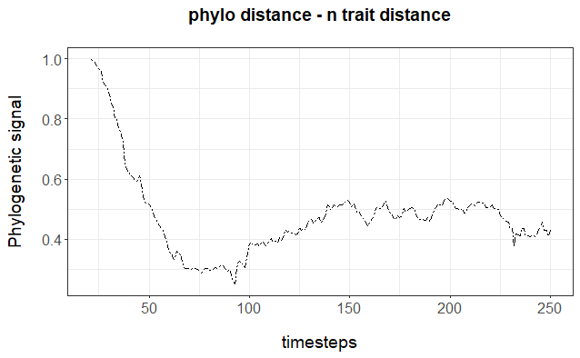

```r
my.theme<-theme(axis.text=element_text(size=12),
                axis.title = element_text(size = 14),
                legend.position = "top",
                legend.text=element_text(size=10),
                legend.title = element_text(size=12),
                plot.title = element_text(face="bold",size=14,margin=margin(0,0,20,0),hjust = 0.5),
                axis.title.y = element_text(margin = margin(t = 0, r = 15, b = 0, l = 0)),
                axis.title.x = element_text(margin = margin(t = 15, r = 0, b = 0, l = 0)))


p_phylo_niche <- ggplot(df_signal_time, aes(x=timesteps, y=protest_niche_corr)) +
       geom_line(color="black", linetype="twodash")+
  #geom_point(aes(fill = sign_mean, color=sign_mean), size=2, alpha = 0.7) +
  theme_bw()+
    my.theme+
    scale_colour_manual(values = c("black", "red"))+
    ggtitle("phylo distance - n trait distance")+
xlab("timesteps")+
  ylab("Phylogenetic signal")

p_phylo_niche
```

```r
NA
NA
```

### Plot species richness through time

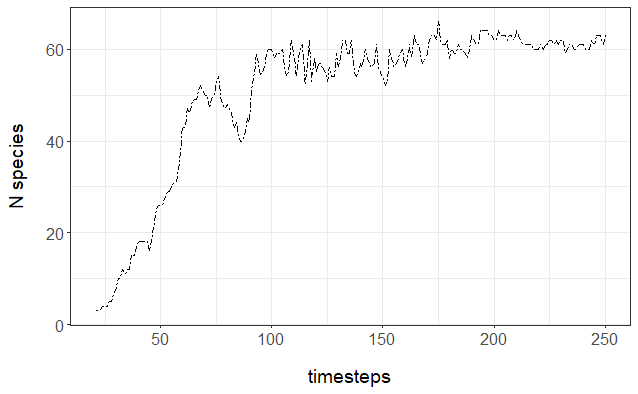

```r
# SHOW ALSO NUMBER OF SPECIES IN THE GRAPH


n_spp_time <- c()

presence_matrix_cropped <- list_simulation1$presence_matrix[timesteps,]

for (i in 1:nrow(presence_matrix_cropped)) {

  n_spp_time[i] <- length(which(presence_matrix_cropped[i,] == 1))

}

df_signal_time$nspp <- n_spp_time


p.spp <- ggplot(df_signal_time, aes(x=timesteps, y = nspp)) +
  geom_line(color="black", linetype="twodash") +
  theme_bw()+
  my.theme+
  scale_colour_manual(values = c("black", "red"))+
  xlab("timesteps")+
  ylab("N species")

p.spp
```